# Lending_club analysis

```python
import folium
import pandas as pd
import matplotlib.pyplot as plt
import seaborn as sns
import plotly.express as px
import numpy as np
import plotly.graph_objects as go
from datetime import datetime, timedelta
from heatmap import heatmap, corrplot
sns.set(color_codes=True, font_scale=1.2)

%matplotlib inline
```

## Data Analysis and Cleaning

[figure not shown]

```python
df = pd.read_csv("Downloads/loans_full_schema.csv")
df.info()
```

```
<class 'pandas.core.frame.DataFrame'>
RangeIndex: 10000 entries, 0 to 9999
Data columns (total 55 columns):
 #   Column                            Non-Null Count  Dtype
---  ------                            --------------  -----
 0   emp_title                         9167 non-null   object
 1   emp_length                        9183 non-null   float64
 2   state                             10000 non-null  object
 3   homeownership                     10000 non-null  object
 4   annual_income                     10000 non-null  float64
 5   verified_income                   10000 non-null  object
 6   debt_to_income                    9976 non-null   float64
 7   annual_income_joint               1495 non-null   float64
 8   verification_income_joint         1455 non-null   object
 9   debt_to_income_joint              1495 non-null   float64
```

[output cut: 47 more lines]

We drop the columns that contain a lot of missing values (more than 75% missing values). While "months_since_last_delinq" column also has significant missing values (5658/1000 missing), we decide to keep this in as we suspect that lenders might weigh this highly.

```python
df.drop(["annual_income_joint", "verification_income_joint", "debt_to_income_joint", "months_since_90d_late"], axis=1, inplace= True)
```

```python
df_states = df.groupby('state', sort=False)["interest_rate"].mean().reset_index(name ='interest_rate')
# for col in df.columns:
#     df[col] = df[col].astype(str)
df_states['text'] = df_states['state'] + '<br>' + 'Interest Rate' + df_states['interest_rate'].astype(str)

fig = go.Figure(data=go.Choropleth(
    locations=df_states['state'],
    z=df_states['interest_rate'],
    locationmode='USA-states',
    colorscale='Blues',
    autocolorscale=False,
    text=df_states['text'], # hover text
    marker_line_color='darkgray', # line markers between states
    colorbar_title="Percentage"
))

fig.update_layout(
    title_text='Average Interest Rate by State<br> (Hover over state to see individual rates)',
    geo = dict(
        scope='usa',
        projection=go.layout.geo.Projection(type = 'albers usa'),
        showlakes=True, # lakes
        lakecolor='rgb(255, 255, 255)'),
)

fig.show()
```

[interactive chart not shown]

Let's now view some basic statistics about the the numeric columns.

```python
df.describe()
```

|  | emp_length | annual_income | debt_to_income | delinq_2y | months_since_last_delinq | earliest_credit_line | inquiries_last_12m | total_credit_lines | open_credit_lines | total_credit_limit | ... | public_record_bankrupt | loan_amount | term | interest_rate | installment | balance | paid_total | paid_principal | paid_interest | paid_late_fees |
| --- | --- | --- | --- | --- | --- | --- | --- | --- | --- | --- | --- | --- | --- | --- | --- | --- | --- | --- | --- | --- | --- |
| count | 9183.000000 | 1.000000e+04 | 9976.000000 | 10000.00000 | 4342.000000 | 10000.00000 | 10000.00000 | 10000.000000 | 10000.00000 | 1.000000e+04 | ... | 10000.000000 | 10000.000000 | 10000.000000 | 10000.000000 | 10000.000000 | 10000.000000 | 10000.000000 | 10000.000000 | 10000.000000 | 10000.000000 |
| mean | 5.930306 | 7.922215e+04 | 19.308192 | 0.21600 | 36.760709 | 2001.29000 | 1.95820 | 22.679600 | 11.40440 | 1.836062e+05 | ... | 0.123800 | 16361.922500 | 43.272000 | 12.427524 | 476.205323 | 14458.916610 | 2494.234773 | 1894.448466 | 599.666781 | 0.119516 |
| std | 3.703734 | 6.473429e+04 | 15.004851 | 0.68366 | 21.634939 | 7.79551 | 2.38013 | 11.885439 | 5.86828 | 1.876327e+05 | ... | 0.337172 | 10301.956759 | 11.029877 | 5.001105 | 294.851627 | 9964.561865 | 3958.230365 | 3884.407175 | 517.328062 | 1.813468 |
| min | 0.000000 | 0.000000e+00 | 0.000000 | 0.00000 | 1.000000 | 1963.00000 | 0.00000 | 2.000000 | 0.00000 | 0.000000e+00 | ... | 0.000000 | 1000.000000 | 36.000000 | 5.310000 | 30.750000 | 0.000000 | 0.000000 | 0.000000 | 0.000000 | 0.000000 |
| 25% | 2.000000 | 4.500000e+04 | 11.057500 | 0.00000 | 19.000000 | 1997.00000 | 0.00000 | 14.000000 | 7.00000 | 5.159375e+04 | ... | 0.000000 | 8000.000000 | 36.000000 | 9.430000 | 256.040000 | 6679.065000 | 928.700000 | 587.100000 | 221.757500 | 0.000000 |
| 50% | 6.000000 | 6.500000e+04 | 17.570000 | 0.00000 | 34.000000 | 2003.00000 | 1.00000 | 21.000000 | 10.00000 | 1.146670e+05 | ... | 0.000000 | 14500.000000 | 36.000000 | 11.980000 | 398.420000 | 12379.495000 | 1563.300000 | 984.990000 | 446.140000 | 0.000000 |
| 75% | 10.000000 | 9.500000e+04 | 25.002500 | 0.00000 | 53.000000 | 2006.00000 | 3.00000 | 29.000000 | 14.00000 | 2.675500e+05 | ... | 0.000000 | 24000.000000 | 60.000000 | 15.050000 | 644.690000 | 20690.182500 | 2616.005000 | 1694.555000 | 825.420000 | 0.000000 |
| max | 10.000000 | 2.300000e+06 | 469.090000 | 13.00000 | 118.000000 | 2015.00000 | 29.00000 | 87.000000 | 51.00000 | 3.386034e+06 | ... | 3.000000 | 40000.000000 | 60.000000 | 30.940000 | 1566.590000 | 40000.000000 | 41630.443684 | 40000.000000 | 4216.440000 | 52.980000 |

8 rows × 39 columns

```python
df.drop(['paid_total','paid_principal','paid_interest',
         'paid_late_fees','grade', 'sub_grade'] ,1, inplace=True)
```

We don't see any obvious logical discrepancies in the data- any weird values etc. So we keep the numerical data as is.

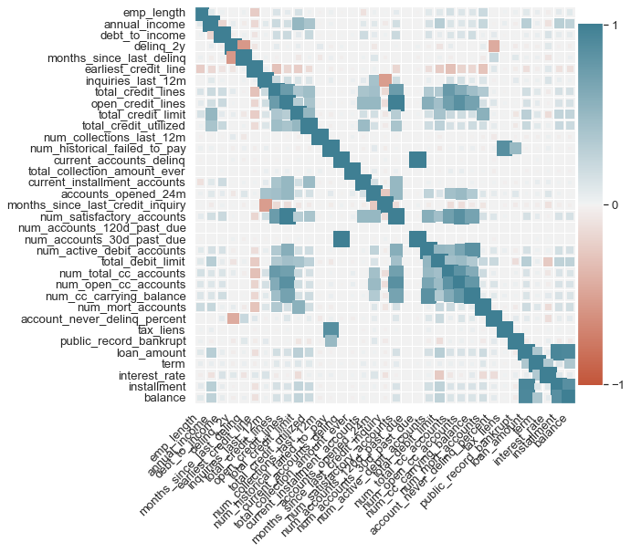

```python
plt.figure(figsize=(8, 8))
plt.title('Interest rate is NOT highly correlated with any single variable')
corrplot(df.corr(), size_scale=300);
```

We make the above correlation heatmap that uses more than just colors to show correlations- making it easier to read, especially in the presence of a large number of variables. For a start, we do not see any single variable that the interest rate is directly highly correlated with.

### Employee Title

emp_title might be a free text field on the application form or a list of currated employment titles. Let’s examine how many unique values exist:

```python
print(df.emp_title.value_counts().head())
print(df.emp_title.value_counts().tail())
df.emp_title.unique().shape
```

```
manager    218
owner      204
teacher    201
driver     123
sales       97
Name: emp_title, dtype: int64
r e appraiser          1
hris analyst           1
parts                  1
evs lead               1
evidence technician    1
Name: emp_title, dtype: int64
```

```
(4742,)
```

Applying this example to our dataset, Registered Nurses, or RNs, who have higher education requirements and receive above average pay, might be granted A grade loans on average. Is this due to them working as RNs or having a regular source of income or having a 4-year degree or their salary? Would we see the same effect for Physician Assistants who go to school for longer and receive even more pay? What about Certified Nursing Assistants (CNAs) who are on the oppposite spectrum?

[figure not shown]

### Employment Length

Leaving this variable in might contradict our decision to drop the employment tile since it conveys socio-economic seniority. A Computer Scientist 5 years into their career would generally have a larger salary than a Kindergarden teacher 10 years into their career. Arguably it might be powerful to combine a grouped, matched, and reduced set of employment titles with their length to create a “purchasing power” metric. However, since employment length is an easy scalar, let’s leave it in for now.

### Visualizing income rates with probability of loan payment

```python
def fully_paid(loan_status):
    if (loan_status == 'Fully Paid')| (loan_status=='Does not meet the credit policy. Status:Fully Paid'):
        return(1)
    elif (loan_status == 'Charged Off') | (loan_status=='Does not meet the credit policy. Status:Charged Off'):
        return(0)
    else:
        return(-1)
df['Paid'] = df['loan_status'].apply(fully_paid)
df_paid = df[df['Paid']!=-1]

print('Maximum annual income',max(df_paid['annual_income']))
print('Minimum annual income',min(df_paid['annual_income']))
print('Mean annual income',df_paid['annual_income'].mean())
```

```
Maximum annual income 2300000.0
Minimum annual income 0.0
Mean annual income 86561.94810572687
```

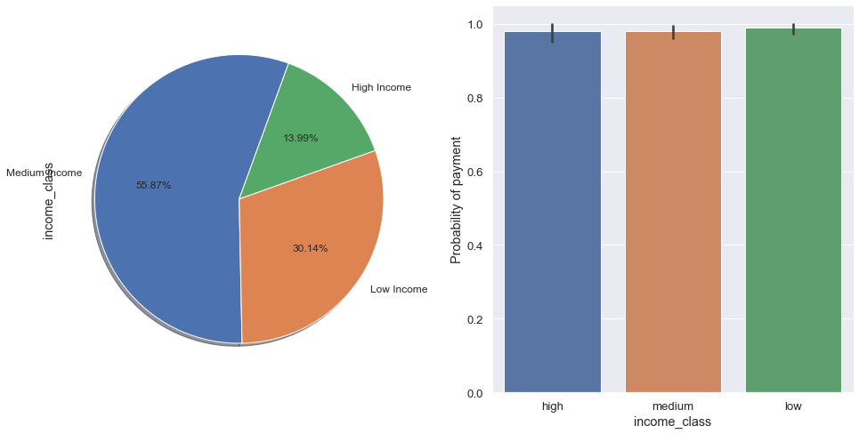

```python
def income_class(income):
    if income<50000:
        return 'low'
    if (income>50000) and (income<120000):
        return 'medium'
    if income>120000:
        return 'high'
df['income_class'] = df['annual_income'].apply(income_class)

f, ax = plt.subplots(1,2, figsize=(16,8))

labels = ['Medium Income','Low Income', 'High Income']
df["income_class"].value_counts().plot.pie(autopct='%1.2f%%', ax=ax[0], shadow=True,
                                           labels=labels, fontsize=12, startangle=70)


sns.barplot(x="income_class", y="Paid", data=df_paid)
ax[1].set(ylabel="Probability of payment")
f.show()
```

30% of borrowers have low income (Annual income < 50000 dollars), 56% medium income (120000 dollars > Annual income> 50000 dollars) and 14% high income (Annual income > 120000 dollars).

The probability of payment appears independent of income classification.

```python
df.drop(["Paid", "income_class"], axis=1, inplace= True)
```

### Loan Status

Loan status is mutable value that represents the current state of the loan. If anything we might want to examine if all the independent variables and/or interst rate to determine the probability of the loan status at some time. In this work we want to predict the interest rate granted to an applicant at loan creation. Thus we do not care about this variable and will drop it after examining it.

```python
print(df.loan_status.value_counts())
df.drop(['loan_status'],1, inplace=True)
```

```
Current               9375
Fully Paid             447
In Grace Period         67
Late (31-120 days)      66
Late (16-30 days)       38
Charged Off              7
Name: loan_status, dtype: int64
```

### Issue Month and other string variables

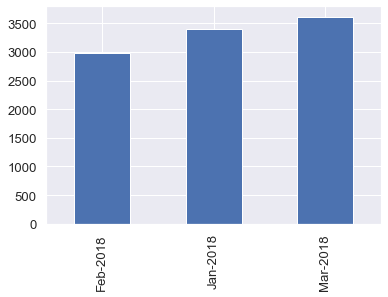

```python
df.issue_month.value_counts().sort_index().plot(kind='bar')
```

### Post Loan Attributes

```python
print(df.homeownership.value_counts())
print(df.loan_purpose.value_counts())
print(df.application_type.value_counts())
print(df.initial_listing_status.value_counts())
print(df.disbursement_method.value_counts())
```

```
MORTGAGE    4789
RENT        3858
OWN         1353
Name: homeownership, dtype: int64
debt_consolidation    5144
credit_card           2249
other                  914
home_improvement       680
major_purchase         303
medical                162
house                  151
car                    131
small_business         125
moving                  69
vacation                62
renewable_energy        10
Name: loan_purpose, dtype: int64
individual    8505
joint         1495
Name: application_type, dtype: int64
whole         8206
fractional    1794
Name: initial_listing_status, dtype: int64
Cash         9284
DirectPay     716
Name: disbursement_method, dtype: int64
```

```python
for col in ['issue_month', 'state', 'homeownership', 'loan_purpose', 'application_type','initial_listing_status','disbursement_method']:
    df[col] = df[col].astype('category')
```

```python
features = ['emp_length', 'state', 'homeownership', 'annual_income', 'debt_to_income', 'delinq_2y',
       'months_since_last_delinq', 'earliest_credit_line',
       'inquiries_last_12m', 'total_credit_lines', 'open_credit_lines',
       'total_credit_limit', 'total_credit_utilized',
       'num_collections_last_12m', 'num_historical_failed_to_pay',
       'current_accounts_delinq', 'total_collection_amount_ever',
       'current_installment_accounts', 'accounts_opened_24m',
       'months_since_last_credit_inquiry', 'num_satisfactory_accounts',
       'num_accounts_120d_past_due', 'num_accounts_30d_past_due',
       'num_active_debit_accounts', 'total_debit_limit',
       'num_total_cc_accounts', 'num_open_cc_accounts',
       'num_cc_carrying_balance', 'num_mort_accounts',
       'account_never_delinq_percent', 'tax_liens', 'public_record_bankrupt',
       'loan_purpose', 'application_type', 'loan_amount', 'term', 'installment',
       'disbursement_method', 'balance']
target = 'interest_rate'

final_df = df[features + [target]]
```

```python
categorical_variables = []
for feat_name, feat_type in zip(final_df.columns, final_df.dtypes):
    if feat_type.name == 'category':
        categorical_variables.append(feat_name)

for feature in categorical_variables:

    final_df_one_hot_encoded = pd.get_dummies(final_df[feature],prefix=feature)
    #print loans_one_hot_encoded

    final_df = final_df.drop(feature, axis=1)
    for col in final_df_one_hot_encoded.columns:
        final_df[col] = final_df_one_hot_encoded[col]

print(final_df.head(2))
print(final_df.columns)
```

```
   emp_length  annual_income  debt_to_income  delinq_2y  \
0         3.0        90000.0           18.01          0
1        10.0        40000.0            5.04          0

   months_since_last_delinq  earliest_credit_line  inquiries_last_12m  \
0                      38.0                  2001                   6
1                       NaN                  1996                   1

   total_credit_lines  open_credit_lines  total_credit_limit  ...  \
0                  28                 10               70795  ...
1                  30                 14               28800  ...

   loan_purpose_medical  loan_purpose_moving  loan_purpose_other  \
0                     0                    1                   0
1                     0                    0                   0

   loan_purpose_renewable_energy  loan_purpose_small_business  \
0                              0                            0
1                              0                            0

   loan_purpose_vacation  application_type_individual  application_type_joint  \
0                      0                            1                       0
1                      0                            1                       0

   disbursement_method_Cash  disbursement_method_DirectPay
0                         1                              0
1                         1                              0

[2 rows x 104 columns]
Index(['emp_length', 'annual_income', 'debt_to_income', 'delinq_2y',
       'months_since_last_delinq', 'earliest_credit_line',
       'inquiries_last_12m', 'total_credit_lines', 'open_credit_lines',
       'total_credit_limit',
       ...
       'loan_purpose_medical', 'loan_purpose_moving', 'loan_purpose_other',
       'loan_purpose_renewable_energy', 'loan_purpose_small_business',
       'loan_purpose_vacation', 'application_type_individual',
       'application_type_joint', 'disbursement_method_Cash',
       'disbursement_method_DirectPay'],
      dtype='object', length=104)
```

```python
def clean_dataset(df):
    assert isinstance(df, pd.DataFrame), "df needs to be a pd.DataFrame"
    df.dropna(inplace=True)
    indices_to_keep = ~df.isin([np.nan, np.inf, -np.inf]).any(1)
    return df[indices_to_keep].astype(np.float64)
```

## Training and Prediction

[figure not shown]

### Simple - Linear Regression

```python
from sklearn import datasets, linear_model
from sklearn.model_selection import train_test_split

y = final_df.interest_rate
X_train, X_test, y_train, y_test = train_test_split(final_df, y, test_size=0.2)
```

```python
lm = linear_model.LinearRegression()
model = lm.fit(X_train, y_train)
predictions = lm.predict(X_test)
print("Score {}".format(model.score(X_test, y_test)))
```

```
Score 1.0
```

### Gradient boosted Regression Trees

We won’t spend too much time in this tuning, but in general GBTs give us threes knobs we can tune for overfitting: (1) Tree Structure, (2) Shrinkage, (3) Stochastic Gradient Boosting. In the interest of time we’ll do a simple grid search amongst a hand chosen set of hyper-parameters.

One of the most effective paramerters to tune for when working with a large feature set is max_features as it introduces a notion of randomization similar to Random Forests. Playing with max features allows us to perform subsampling of our feature space before finding the best split node. A max_features setting of .20 for example would grow each tree on 20% of the featureset. Conversely the subsample feature would use 20% of the training data (all features). Subsample interacts with the parameter n_estimators. Choosing subsample < 1.0 leads to a reduction of variance and an increase in bias.

```python
from sklearn import ensemble
from sklearn import datasets
from sklearn.utils import shuffle
from sklearn.metrics import mean_squared_error
from matplotlib import pyplot as plt
```

```python
from sklearn.model_selection import GridSearchCV
param_grid = {'learning_rate': [0.1, 0.05, 0.02, 0.01],
              'max_depth': [4, 6],
              'min_samples_leaf': [3, 5, 9, 17],
              'max_features': [1.0, 0.3, 0.1]
              }
# param_grid = {'learning_rate': [0.1],
#               'max_depth': [4],
#               'min_samples_leaf': [3],
#               'max_features': [1.0],
#               }

est = GridSearchCV(ensemble.GradientBoostingRegressor(n_estimators=100),
                   param_grid, n_jobs=4, refit=True)

est.fit(X_train, y_train)

best_params = est.best_params_
```

```python
%%time
est = ensemble.GradientBoostingRegressor(n_estimators=2000).fit(X_train, y_train)
```

```
CPU times: user 17.9 s, sys: 97.2 ms, total: 18 s
Wall time: 18 s
```

```python
est.score(X_test,y_test)
```

```
0.9999999957107917
```

[output not shown]

[figure not shown]

```python
sns.set(font_scale=1, rc={"lines.linewidth":1.2})


Iterations = 2000
# compute test set deviance
test_score = np.zeros((Iterations,), dtype=np.float64)

for i, y_pred in enumerate(est.staged_predict(X_test)):
    test_score[i] = est.loss_(y_test, y_pred)

plt.figure(figsize=(14, 6)).subplots_adjust(wspace=.3)

plt.subplot(1, 2, 1)
plt.title('Deviance over iterations')
plt.plot(np.arange(Iterations) + 1, est.train_score_, 'dodgerblue',
         label='Training Set Deviance', alpha=.6)
plt.plot(np.arange(Iterations) + 1, test_score, 'firebrick',
         label='Test Set Deviance', alpha=.6)
plt.legend(loc='upper right')
plt.xlabel('Boosting Iterations')
plt.ylabel('Deviance')


plt.subplot(1, 2, 2,)
# Top Ten
feature_importance = est.feature_importances_
feature_importance = 100.0 * (feature_importance / feature_importance.max())

indices = np.argsort(feature_importance)[-10:]
plt.barh(np.arange(10), feature_importance[indices],color='dodgerblue',alpha=.4)
plt.yticks(np.arange(10), np.array(df.columns)[indices])
_ = plt.xlabel('Relative importance'), plt.title('Top Ten Important Variables')
```

There is some bug in the gradient boost- given more time, I would fix the error.

I also understand that the training and prediction part has a LOT of scope for improvement as I hurried through it- so adding in more visualizations to make it easy for the layperson audience would be a top priority.